# Lab Assignment SIX: Convolutional Neural Networks

## Team Members

1. Piyush Metkar - 47509180
2. Rishab Vaishya - 47505527
3. Dhaval Gogri - 47444609

# BUSINESS UNDERSTANDING

REFERENCE : https://www.kaggle.com/moltean/fruits/data

This dataset is taken from Kaggle and it is about different type of fruits whose images are taken at different angles in 360 degrees. The photos have been taken by first keeping the fruit in vertical standing position and then by laying it in horizontal position. 360 degrees gives you an angle from each and every side making accuracy pretty high.

The study of this project will help companies such as Tropicana which sell fruit packets, fruit juices, or anything related to fruit. The company might have a manufacturing facility where many different kinds of fruit products are made. This model can be implemented for automating processes such as sorting of fruits according to their kind.

When the container of these fruits arrive at the manufacturing facility, the software will recognize the fruit by using our machine learning algorithm and send the container to its respective place. It is very important to have a very high accuracy in this regard as one fruit cannot be mixed with another fruit. Because if some fruit is mixed with another fruit like banana with litchie, it will spoil the entire batch.

Further development in this study will also help in detecting fruit quality depending on the size, shape, color and texture etc which in turn would help throw away rotten fruit and only keep the fresh and the quality ones.

This technique when implemented can also be useful for other food product other than fruits like food grains, meat etc subject to availability of those respective images to train the dataset.

Even while farming, the quality of the fruit can be continuously monitored and data can be collected about its growth. If any issue is found, corrective measures can be taken immediately to prevent any losses to farmers.

For this case we are looking the model to perform at really good rate and expect accuracy more than 90%.

# 1. GRADING RUBRIC

## 1.1 Evaluation Metric

The business case that we are considering for this project is a situation where we will be segregating the fruits as per their types. After the frutis are segregated, they will go to their respective jobs which could be either getting juice, pulp, jams or even shampoo depending on fruit type.

So it is important to identitfy the correct fruit and classify it in proper type. Let's say we are segregating a batch of apples and there comes one litchie among the apples which is falsely classified as an apple. If this litchie goes unnoticed with all the apples to get juice, it will not only spoil the entire batch of apple. But also will cause serious health issues to customers having allergy due to litchie who will buy the product thinking apple juice.

Hence the evaluation metric that we will be choosing is **Accuracy and precision** because we want higher number of true positives and lower number of false positives.

## 1.2 Cross Validation

Also in the dataset, we have separate test data included. Hence the trained model will be tested on the test data.

# 2. Modeling

We are using the following reference to import the data images from dataset and thus preparing the data for model.

https://www.kaggle.com/naveenc131/cnn-with-accuracy-of-98

## 2.1 Data Expansion

Let's consider an example where there are multiple fruits which are travelling on a conveyor belt. These fruits may be present in any orientation. In dataset, we have images taken in such a way that each fruit is kept vertically standing and horizontally laid down position and then the images are taken from all the angles. This doesn't actually cover the upside down orientation of the fruit.

```python
import numpy as np # linear algebra
import pandas as pd # data processing, CSV file I/O (e.g. pd.read_csv)
import keras
import tensorflow as tf
import matplotlib.pyplot as plt
%matplotlib inline
import cv2
import glob
import os

import itertools

from keras.models import Sequential,Model
from keras.layers import Dense,Dropout,Conv2D,MaxPooling2D,Flatten,Activation,BatchNormalization
from keras.optimizers import Adamax
from keras.layers.advanced_activations import LeakyReLU
from keras import backend as K

from keras.callbacks import Callback
from sklearn.metrics import confusion_matrix, f1_score, precision_score, recall_score, accuracy_score

from sklearn.preprocessing import StandardScaler
from sklearn import metrics as mt
from sklearn.neural_network import MLPClassifier
```

```python
def rgb2gray(rgb):
    return np.dot(rgb[...,:3], [0.299, 0.587, 0.114])
```

```python
#ref: https://www.kaggle.com/naveenc131/cnn-with-accuracy-of-98
IMAGE_SIZE = 100

training_fruit_img = []
training_label = []

training_fruit_img_bw = []
training_label_bw = []

# for dir_path in glob.glob("/Users/piyushmetkar/Documents/SMU/Notes/Spring 18/7324 Machine Learning in Python/Lab 6/fruits-360/Training/*"):
#     img_label = dir_path.split("/")[-1]
for dir_path in glob.glob(r'C:\ML\fruits-360_dataset_2018_02_08\Training\*'):
    img_label = dir_path.split("\\")[-1]

    for image_path in glob.glob(os.path.join(dir_path,"*.jpg")):
        #Read the images
        image = cv2.imread(image_path,cv2.IMREAD_COLOR)
        image = cv2.resize(image, (IMAGE_SIZE, IMAGE_SIZE))

        image_bw = rgb2gray(image)    #Grayscale images for MLP

        image = cv2.cvtColor(image, cv2.COLOR_RGB2BGR)        #OpenCV swaps the Red and Blue channels while reading images.
        image_vf =  cv2.flip( image, 1 )                      #Vertically flipping images for data expansion


        image_bw = image_bw.flatten()

        training_fruit_img.append(image)
        training_fruit_img.append(image_vf)
        training_fruit_img_bw.append(image_bw)

        training_label.append(img_label)
        training_label.append(img_label)
        training_label_bw.append(img_label)

training_fruit_img = np.array(training_fruit_img)
training_fruit_img_bw = np.array(training_fruit_img_bw)
training_label = np.array(training_label)
training_label_bw = np.array(training_label_bw)

print(training_fruit_img.shape)
print(training_fruit_img_bw.shape)
```

```
(57472, 100, 100, 3)
(28736, 10000)
```

```python
label_to_id = {v:k for k,v in enumerate(np.unique(training_label)) }
id_to_label = {v:k for k,v in label_to_id.items() }

id_to_label
```

```
{0: 'Apple Braeburn',
 1: 'Apple Golden 1',
 2: 'Apple Golden 2',
 3: 'Apple Golden 3',
 4: 'Apple Granny Smith',
 5: 'Apple Red 1',
 6: 'Apple Red 2',
 7: 'Apple Red 3',
 8: 'Apple Red Delicious',
 9: 'Apple Red Yellow',
 10: 'Apricot',
 11: 'Avocado',
 12: 'Avocado ripe',
 13: 'Banana',
 14: 'Banana Red',
```

[output cut: 45 more lines]

```python
training_label_id = np.array([label_to_id[i] for i in training_label])
training_label_bw_id = np.array([label_to_id[i] for i in training_label_bw])

training_label_id.shape, training_label_bw_id.shape
```

```
((57472,), (28736,))
```

```python
validation_fruit_img=[]
validation_label =[]
validation_fruit_img_bw =[]

# for dir_path in glob.glob("/Users/piyushmetkar/Documents/SMU/Notes/Spring 18/7324 Machine Learning in Python/Lab 6/fruits-360/Validation/*"):
#     img_label = dir_path.split("/")[-1]
for dir_path in glob.glob(r'C:\ML\fruits-360_dataset_2018_02_08\Validation\*'):
    img_label = dir_path.split("\\")[-1]

for image_path in glob.glob(os.path.join(dir_path,"*.jpg")):
        image = cv2.imread(image_path,cv2.IMREAD_COLOR)
        image = cv2.resize(image, (IMAGE_SIZE, IMAGE_SIZE))
        image = cv2.cvtColor(image, cv2.COLOR_RGB2BGR)
        image_bw = cv2.cvtColor(image, cv2.COLOR_BGR2GRAY)

        validation_fruit_img.append(image)
        validation_fruit_img_bw.append(image_bw)
        validation_label.append(img_label)

validation_fruit_img = np.array(validation_fruit_img)
validation_fruit_img_bw = np.array(validation_fruit_img_bw)
validation_label = np.array(validation_label)

validation_label_id = np.array([label_to_id[i] for i in validation_label])

validation_fruit_img.shape,validation_label_id.shape
```

```
((166, 100, 100, 3), (166,))
```

```python
X_train,X_test = training_fruit_img,validation_fruit_img
Y_train,Y_test =training_label_id,validation_label_id
#mean(X) = np.mean(X_train)
X_train = X_train/255
X_test = X_test/255

X_flat_train = X_train.reshape(X_train.shape[0],IMAGE_SIZE*IMAGE_SIZE*3)
X_flat_test = X_test.reshape(X_test.shape[0],IMAGE_SIZE*IMAGE_SIZE*3)

#One Hot Encode the Output
Y_train = keras.utils.to_categorical(Y_train, 60)
Y_test = keras.utils.to_categorical(Y_test, 60)

print('Original Sizes:', X_train.shape, X_test.shape, Y_train.shape, Y_test.shape)
print('Flattened:', X_flat_train.shape, X_flat_test.shape)
```

```
Original Sizes: (57472, 100, 100, 3) (166, 100, 100, 3) (57472, 60) (166, 60)
Flattened: (57472, 30000) (166, 30000)
```

```
(100, 100, 3)
```

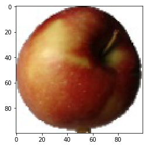

```
Apple Braeburn
```

```python
print(X_train[500].shape)
plt.imshow(X_train[500])

plt.show()
#print(Y_train[490])
print(id_to_label[np.argmax(Y_train[500], axis=None, out=None)])
```

```python
class Metrics(Callback):
    def on_train_begin(self, logs={}):
        self.val_accs = []
        self.val_f1s = []
        self.val_recalls = []
        self.val_precisions = []

    def on_epoch_end(self, epoch, logs={}):
        val_predict = (np.asarray(self.model.predict(self.validation_data[0]))).round()
        val_targ = self.validation_data[1]
        _val_acc = accuracy_score(val_targ, val_predict)
        _val_f1 = f1_score(val_targ, val_predict, average='micro')
        _val_recall = recall_score(val_targ, val_predict, average='micro')
        _val_precision = precision_score(val_targ, val_predict, average='micro')
        self.val_accs.append(_val_acc)
        self.val_f1s.append(_val_f1)
        self.val_recalls.append(_val_recall)
        self.val_precisions.append(_val_precision)
        print ('val_precision:', _val_precision)# — val_acc: %f — val_precision: %f — val_recall %f” %(_val_f1, _val_precision, _val_recall)
        return

metrics = Metrics()
```

```python
# ref: https://www.kaggle.com/danbrice/keras-plot-history-full-report-and-grid-search
import matplotlib.pyplot as plt
import itertools

def plot_history(history):
    loss_list = [s for s in history.history.keys() if 'loss' in s and 'val' not in s]
    val_loss_list = [s for s in history.history.keys() if 'loss' in s and 'val' in s]
    acc_list = [s for s in history.history.keys() if 'acc' in s and 'val' not in s]
    val_acc_list = [s for s in history.history.keys() if 'acc' in s and 'val' in s]

    if len(loss_list) == 0:
        print('Loss is missing in history')
        return

    ## As loss always exists
    epochs = range(1,len(history.history[loss_list[0]]) + 1)


    ## Loss
    plt.rcParams["figure.figsize"] = (20,6)
    plt.subplot(1, 2, 1)
#     plt.figure(figsize=(10,6))
    for l in loss_list:
        plt.plot(epochs, history.history[l], 'b', label='Training loss (' + str(str(format(history.history[l][-1],'.5f'))+')'))
    for l in val_loss_list:
        plt.plot(epochs, history.history[l], 'g', label='Validation loss (' + str(str(format(history.history[l][-1],'.5f'))+')'))

    plt.title('Loss')
    plt.xlabel('Epochs')
    plt.ylabel('Loss')
    plt.legend()

    plt.subplot(1, 2, 2)
    ## Accuracy
#     plt.figure(figsize=(10,6))
    for l in acc_list:
        plt.plot(epochs, history.history[l], 'b', label='Training accuracy (' + str(format(history.history[l][-1],'.5f'))+')')
    for l in val_acc_list:
        plt.plot(epochs, history.history[l], 'g', label='Validation accuracy (' + str(format(history.history[l][-1],'.5f'))+')')

    plt.title('Accuracy')
    plt.xlabel('Epochs')
    plt.ylabel('Accuracy')
    plt.legend()
    plt.show()
```

## 2.2 CNN Models

### Model 1

```python
def decode_OHE(encoded_arr):
    decoded = np.zeros(encoded_arr.shape[0])
    temp = 0
    for i in range(encoded_arr.shape[0]):
        decoded[temp] = val = np.argmax(encoded_arr[i])
        temp = temp + 1
    return decoded

accuracy_vals = np.zeros(6)
precision_vals = np.zeros(6)
#names[]
```

```python
model1 = Sequential()
model1.add(Conv2D(8,(2,2),input_shape=(IMAGE_SIZE,IMAGE_SIZE,3),padding='same'))
model1.add(Activation("relu"))
model1.add(BatchNormalization())
model1.add(MaxPooling2D(pool_size=(4,4)))

model1.add(Flatten())
model1.add(Dense(256,activation='relu'))
model1.add(LeakyReLU(0.1))
model1.add(Dropout(0.5))
model1.add(Dense(60))
model1.add(Activation("softmax"))

model1.summary()
```

```
_________________________________________________________________
Layer (type)                 Output Shape              Param #
=================================================================
conv2d_2 (Conv2D)            (None, 100, 100, 8)       104
_________________________________________________________________
activation_3 (Activation)    (None, 100, 100, 8)       0
_________________________________________________________________
batch_normalization_2 (Batch (None, 100, 100, 8)       32
_________________________________________________________________
max_pooling2d_2 (MaxPooling2 (None, 25, 25, 8)         0
_________________________________________________________________
flatten_2 (Flatten)          (None, 5000)              0
_________________________________________________________________
dense_3 (Dense)              (None, 256)               1280256
_________________________________________________________________
leaky_re_lu_2 (LeakyReLU)    (None, 256)               0
_________________________________________________________________
dropout_2 (Dropout)          (None, 256)               0
_________________________________________________________________
dense_4 (Dense)              (None, 60)                15420
_________________________________________________________________
activation_4 (Activation)    (None, 60)                0
=================================================================
Total params: 1,295,812
Trainable params: 1,295,796
Non-trainable params: 16
_________________________________________________________________
```

```python
model1.compile(loss='mean_squared_error',
             optimizer = Adamax(),
             metrics=['accuracy'])

history1 = model1.fit(X_train,
          Y_train,
          batch_size=16,
          epochs=7,
          verbose=1,
          validation_data = (X_test,Y_test),
          callbacks=[metrics]
         )
```

```
Train on 57472 samples, validate on 166 samples
val_precision: 0.9879518072289156
val_precision: 0.7409638554216867
val_precision: 1.0
val_precision: 1.0
val_precision: 1.0
val_precision: 1.0
val_precision: 1.0
```

```
model1 : 16
```

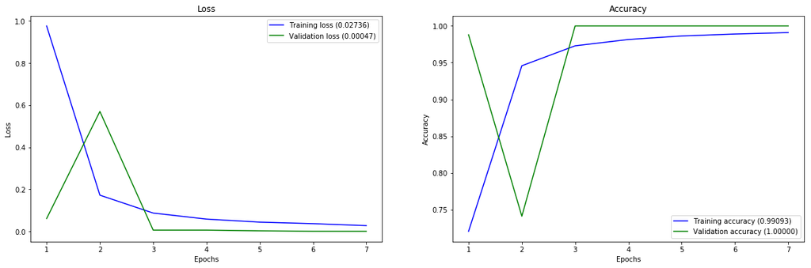

```python
print('model1 : 16')
plot_history(history1)

yhat1 = model1.predict(X_train)
yhat1 = decode_OHE(yhat1)

precision_vals[0] = mt.precision_score(yhat1, training_label_id, average='micro')
accuracy_vals[0] = mt.accuracy_score(yhat1, training_label_id)
#names[0] = ''
```

```python
model1.compile(loss='mean_squared_error',
             optimizer = Adamax(),
             metrics=['accuracy'])

history1 = model1.fit(X_train,
          Y_train,
          batch_size=32,
          epochs=7,
          verbose=1,
          validation_data = (X_test,Y_test),
          callbacks=[metrics]
         )
```

```
Train on 57472 samples, validate on 166 samples
val_precision: 1.0
val_precision: 1.0
val_precision: 1.0
val_precision: 1.0
val_precision: 1.0
val_precision: 1.0
val_precision: 1.0
```

```
model1 : 32
```

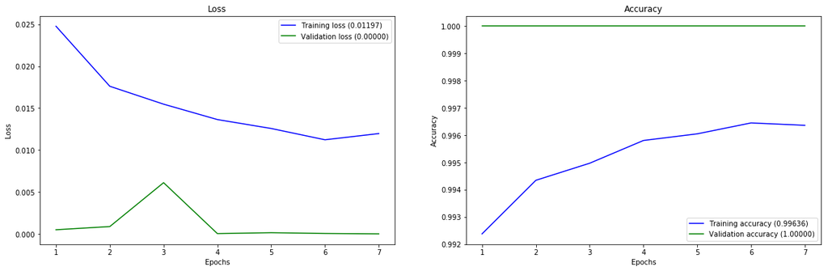

```python
print('model1 : 32')
plot_history(history1)


yhat1 = model1.predict(X_train)
yhat1 = decode_OHE(yhat1)

precision_vals[1] = mt.precision_score(yhat1, training_label_id, average='micro')
accuracy_vals[1] = mt.accuracy_score(yhat1, training_label_id)
```

```python
model1.compile(loss='mean_squared_error',
             optimizer = Adamax(),
             metrics=['accuracy'])

history1 = model1.fit(X_train,
          Y_train,
          batch_size=64,
          epochs=7,
          verbose=1,
          validation_data = (X_test,Y_test),
          callbacks=[metrics]
         )
```

```
Train on 57472 samples, validate on 166 samples
val_precision: 1.0
val_precision: 1.0
val_precision: 1.0
val_precision: 1.0
val_precision: 1.0
val_precision: 1.0
val_precision: 1.0
```

```
model1 = 64
```

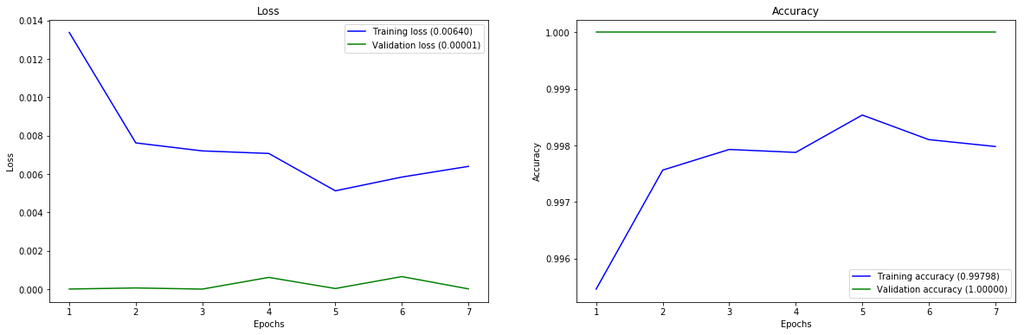

```python
print('model1 = 64')
plot_history(history1)


yhat1 = model1.predict(X_train)
yhat1 = decode_OHE(yhat1)

precision_vals[2] = mt.precision_score(yhat1, training_label_id, average='micro')
accuracy_vals[2] = mt.accuracy_score(yhat1, training_label_id)
```

### Model 2

```python
model2 = Sequential()
model2.add(Conv2D(8,(2,2),input_shape=(IMAGE_SIZE, IMAGE_SIZE,3),padding='same'))
model2.add(LeakyReLU(0.5))
model2.add(BatchNormalization())
model2.add(MaxPooling2D(pool_size=(4,4)))
model2.add(Dropout(0.25))

num_filt_layers = [32,32,64]
for num_filters in num_filt_layers:
    model2.add(Conv2D(filters=num_filters,
                    kernel_size=(3,3),
                    padding='same'))
    model2.add(LeakyReLU(0.5))
    model2.add(MaxPooling2D(pool_size=(2, 2), data_format="channels_first"))


model2.add(Flatten())
model2.add(Dense(256,activation='elu'))
model2.add(LeakyReLU(0.1))
model2.add(Dropout(0.5))
model2.add(Dense(60))
model2.add(Activation("softmax"))

model2.summary()
```

```
_________________________________________________________________
Layer (type)                 Output Shape              Param #
=================================================================
conv2d_7 (Conv2D)            (None, 100, 100, 8)       104
_________________________________________________________________
leaky_re_lu_8 (LeakyReLU)    (None, 100, 100, 8)       0
_________________________________________________________________
batch_normalization_4 (Batch (None, 100, 100, 8)       32
_________________________________________________________________
max_pooling2d_7 (MaxPooling2 (None, 25, 25, 8)         0
_________________________________________________________________
dropout_5 (Dropout)          (None, 25, 25, 8)         0
_________________________________________________________________
conv2d_8 (Conv2D)            (None, 25, 25, 32)        2336
_________________________________________________________________
leaky_re_lu_9 (LeakyReLU)    (None, 25, 25, 32)        0
_________________________________________________________________
max_pooling2d_8 (MaxPooling2 (None, 25, 12, 16)        0
_________________________________________________________________
conv2d_9 (Conv2D)            (None, 25, 12, 32)        4640
_________________________________________________________________
leaky_re_lu_10 (LeakyReLU)   (None, 25, 12, 32)        0
_________________________________________________________________
max_pooling2d_9 (MaxPooling2 (None, 25, 6, 16)         0
_________________________________________________________________
conv2d_10 (Conv2D)           (None, 25, 6, 64)         9280
_________________________________________________________________
leaky_re_lu_11 (LeakyReLU)   (None, 25, 6, 64)         0
_________________________________________________________________
max_pooling2d_10 (MaxPooling (None, 25, 3, 32)         0
_________________________________________________________________
flatten_4 (Flatten)          (None, 2400)              0
_________________________________________________________________
dense_7 (Dense)              (None, 256)               614656
_________________________________________________________________
leaky_re_lu_12 (LeakyReLU)   (None, 256)               0
_________________________________________________________________
dropout_6 (Dropout)          (None, 256)               0
_________________________________________________________________
dense_8 (Dense)              (None, 60)                15420
_________________________________________________________________
activation_6 (Activation)    (None, 60)                0
=================================================================
Total params: 646,468
Trainable params: 646,452
Non-trainable params: 16
_________________________________________________________________
```

```python
model2.compile(loss='mean_squared_error',
             optimizer = Adamax(),
             metrics=['accuracy'])

history2 = model2.fit(X_train,
          Y_train,
          batch_size=16,
          epochs=7,
          verbose=1,
          validation_data = (X_test,Y_test),
          callbacks=[metrics]
         )
```

```
Train on 57472 samples, validate on 166 samples
val_precision: 1.0
val_precision: 1.0
val_precision: 1.0
val_precision: 1.0
val_precision: 1.0
val_precision: 1.0
val_precision: 1.0
```

```
model2 = 16
```

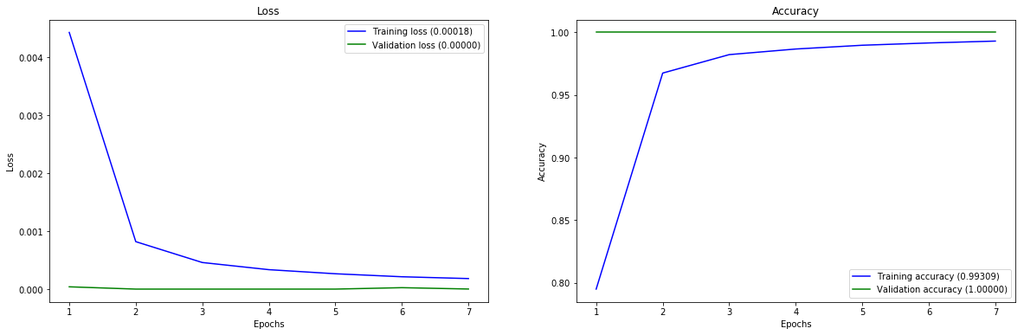

```python
print('model2 = 16')
plot_history(history2)

yhat1 = model1.predict(X_train)
yhat1 = decode_OHE(yhat1)

precision_vals[3] = mt.precision_score(yhat1, training_label_id, average='micro')
accuracy_vals[3] = mt.accuracy_score(yhat1, training_label_id)
```

```python
model2.compile(loss='mean_squared_error',
             optimizer = Adamax(),
             metrics=['accuracy'])

history2 = model2.fit(X_train,
          Y_train,
          batch_size=32,
          epochs=7,
          verbose=1,
          validation_data = (X_test,Y_test),
          callbacks=[metrics]
         )
```

```
Train on 57472 samples, validate on 166 samples
val_precision: 1.0
val_precision: 1.0
val_precision: 1.0
val_precision: 1.0
val_precision: 1.0
val_precision: 1.0
val_precision: 1.0
```

```
model2 = 32
```

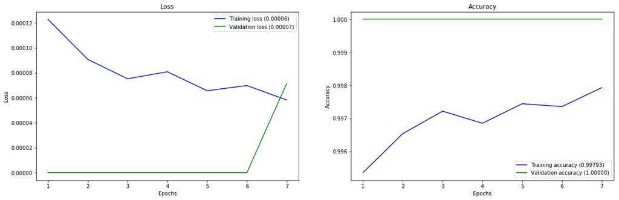

```python
print('model2 = 32')
plot_history(history2)

yhat1 = model1.predict(X_train)
yhat1 = decode_OHE(yhat1)

precision_vals[4] = mt.precision_score(yhat1, training_label_id, average='micro')
accuracy_vals[4] = mt.accuracy_score(yhat1, training_label_id)
```

```python
model2.compile(loss='mean_squared_error',
             optimizer = Adamax(),
             metrics=['accuracy'])

history2 = model2.fit(X_train,
          Y_train,
          batch_size=64,
          epochs=7,
          verbose=1,
          validation_data = (X_test,Y_test),
          callbacks=[metrics]
         )
```

```
Train on 57472 samples, validate on 166 samples
val_precision: 1.0
val_precision: 1.0
val_precision: 1.0
val_precision: 1.0
val_precision: 1.0
val_precision: 1.0
val_precision: 1.0
```

```
model2 = 64
```

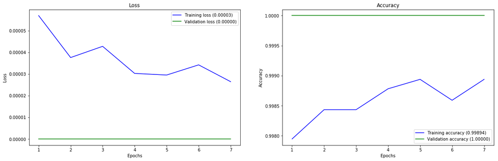

```python
print('model2 = 64')
plot_history(history2)

yhat1 = model1.predict(X_train)
yhat1 = decode_OHE(yhat1)

precision_vals[5] = mt.precision_score(yhat1, training_label_id, average='micro')
accuracy_vals[5] = mt.accuracy_score(yhat1, training_label_id)
```

## 2.4 Comparing with MLP

In order to deploy MLP, We need to make changes to our data. Our data is RGB images which we need to convert into grayscale. Then these images need to be flattedned since we need 2 dimensional training data. Then we divide pixel value by 255 so that we scale the pixel values between 0 and 1. By doing this, out data is ready as input for our MLP.

We are using a Keras MLP model with 3 dense layers followed by a softmax activation function. We are using batch size 8 to avoid loss of data

```python
X_train_bw,X_test_bw = training_fruit_img_bw,validation_fruit_img_bw
Y_train_bw,Y_test_bw = training_label_bw_id,validation_label_id
#mean(X) = np.mean(X_trai
X_train_bw = X_train_bw/255
X_test_bw = X_test_bw/255

X_flat_train_bw = X_train_bw.reshape(X_train_bw.shape[0],IMAGE_SIZE*IMAGE_SIZE*1)
X_flat_test_bw = X_test_bw.reshape(X_test_bw.shape[0],IMAGE_SIZE*IMAGE_SIZE*1)

#One Hot Encode the Output
Y_train_bw = keras.utils.to_categorical(Y_train_bw, 60)
Y_test_bw = keras.utils.to_categorical(Y_test_bw, 60)

print('Original Sizes:', X_train_bw.shape, X_test_bw.shape, Y_train_bw.shape, Y_test_bw.shape)
print('Flattened:', X_flat_train_bw.shape, X_flat_test_bw.shape)

# X1 = training_fruit_img_bw
# y1 = keras.utils.to_categorical(training_label_id, 60)

# make a 3 layer keras MLP
from sklearn import metrics as mt
from keras.models import Sequential,Model
from keras.layers import Dense,Dropout,Conv2D,MaxPooling2D,Flatten,Activation,BatchNormalization
from keras.optimizers import Adamax
from keras.layers.advanced_activations import LeakyReLU
from keras import backend as K

mlp = Sequential()
mlp.add( Dense(input_dim=X_flat_test_bw.shape[1], units=30, activation='relu') )
mlp.add( Dense(units=15, activation='relu') )
mlp.add( Dense(60) )
mlp.add( Activation('softmax') )

mlp.compile(loss='mean_squared_error',
              optimizer='rmsprop',
              metrics=['accuracy'])

mlp.fit(X_flat_train_bw, Y_train_bw,
        batch_size=8, epochs=10,
        shuffle=True, verbose=1)
```

```
Original Sizes: (28736, 10000) (166, 100, 100) (28736, 60) (166, 60)
Flattened: (28736, 10000) (166, 10000)
```

```
<keras.callbacks.History at 0x12ca6418ac8>
```

```python
yhatmlp = mlp.predict(X_flat_test_bw)
yhatmlp = decode_OHE(yhatmlp)

print('Accuracy', mt.accuracy_score(decode_OHE(Y_test_bw),yhatmlp))
print('Precision', mt.precision_score(decode_OHE(Y_test_bw),yhatmlp, average='micro'))
```

```
Accuracy 0.7409638554216867
Precision 0.7409638554216867
```

# 3. EXCEPTIONAL WORK

Ref: https://www.analyticsvidhya.com/blog/2017/06/transfer-learning-the-art-of-fine-tuning-a-pre-trained-model/

Ref: https://medium.com/@14prakash/transfer-learning-using-keras-d804b2e04ef8

Here, we are creating a new dataset by fetching every 10th image from the original dataset. This is done by using the following code.

```python
import os
import shutil, sys

old = r"C:\ML\fruits-360_dataset_2018_02_08\Training"
new = r"C:\ML\fruits-360_dataset_2018_02_08\New_Dataset"
for image_path in glob.glob("C:\ML\fruits-360_dataset_2018_02_08\Training\*"):
    image_label = image_path.split("\\")[-1]
    os.makedirs(os.path.join(new,image_label))
    for idx,image_path in enumerate(glob.glob(os.path.join(image_path,"*.jpg"))):
        image_name = image_path.split("\\")[-1]
        if idx%10==0 :
            shutil.move(image_path,os.path.join(os.path.join(new,image_label),image_name))
```

Once all the images have been copied we get around 50 images in every feature class. Thus the total number of images become 50*60 = 3000 images. I.e. approx 50 images each for 60 feature classes.

```python
training_fruit_img_new = []
training_label_new = []

training_fruit_img_bw_new = []
training_label_bw_new = []


for dir_path in glob.glob(r"C:\ML\fruits-360_dataset_2018_02_08\New_Dataset\*"):
    img_label = dir_path.split("\\")[-1]
# for dir_path in glob.glob(r'D:\Downloads\Notes\CSE_7324_ML\fruits-360_dataset_2018_02_08\Training\*'):
#     img_label = dir_path.split("\\")[-1]
    for image_path in glob.glob(os.path.join(dir_path,"*.jpg")):
        image = cv2.imread(image_path,cv2.IMREAD_COLOR)
        image = cv2.resize(image,  (IMAGE_SIZE, IMAGE_SIZE))
        image = cv2.cvtColor(image, cv2.COLOR_RGB2BGR)
        image_vf =  cv2.flip( image, 1 )
        image_bw = cv2.cvtColor(image,
                                 cv2.COLOR_BGR2GRAY)
#         image_vf_bw =  cv2.flip( image_bw, 1 )
        training_fruit_img_new.append(image)
        training_fruit_img_new.append(image_vf)
        training_fruit_img_bw_new.append(image_bw)
#         training_fruit_img_bw.append(image_vf_bw)
        training_label_new.append(img_label)
        training_label_new.append(img_label)
        training_label_bw_new.append(img_label)
training_fruit_img_new = np.array(training_fruit_img_new)
training_fruit_img_bw_new = np.array(training_fruit_img_bw_new)
training_label_new = np.array(training_label_new)
training_label_bw_new = np.array(training_label_bw_new)

print(training_fruit_img_new.shape)
# print(training_fruit_img_bw.shape)
```

```
(5782, 100, 100, 3)
```

```python
label_to_id_new = {v:k for k,v in enumerate(np.unique(training_label_new)) }
id_to_label_new = {v:k for k,v in label_to_id_new.items() }
training_label_id_new = np.array([label_to_id_new[i] for i in training_label_new])
training_label_id_bw_new = np.array([label_to_id_new[i] for i in training_label_bw_new])
training_fruit_img_new.shape,training_label_id_new.shape
```

```
((5782, 100, 100, 3), (5782,))
```

```python
model_1_new = Sequential()
model_1_new.add(Conv2D(16,(3,3),input_shape=(IMAGE_SIZE,IMAGE_SIZE,3),padding='same'))
model_1_new.add(Activation("relu"))
model_1_new.add(BatchNormalization())
model_1_new.add(MaxPooling2D(pool_size=(2,2)))

model_1_new.add(Flatten())
model_1_new.add(Dense(256,activation='relu'))
model_1_new.add(LeakyReLU(0.1))
model_1_new.add(Dropout(0.5))
model_1_new.add(Dense(60))
model_1_new.add(Activation("softmax"))

model_1_new.add(Dense(60,activation='relu'))
# model_1_new.add(Conv2D(filters = 32,
#                     kernel_size=(3,3),
#                     padding='same'))
model_1_new.add(LeakyReLU(0.5))
model_1_new.add(Dropout(0.1))
# model_1_new.add(MaxPooling2D(pool_size=(2, 2), data_format="channels_first"))
model_1_new.add(Activation("softmax"))

model_1_new.summary()
```

```
_________________________________________________________________
Layer (type)                 Output Shape              Param #
=================================================================
conv2d_11 (Conv2D)           (None, 100, 100, 16)      448
_________________________________________________________________
activation_11 (Activation)   (None, 100, 100, 16)      0
_________________________________________________________________
batch_normalization_5 (Batch (None, 100, 100, 16)      64
_________________________________________________________________
max_pooling2d_11 (MaxPooling (None, 50, 50, 16)        0
_________________________________________________________________
flatten_5 (Flatten)          (None, 40000)             0
_________________________________________________________________
dense_21 (Dense)             (None, 256)               10240256
_________________________________________________________________
leaky_re_lu_13 (LeakyReLU)   (None, 256)               0
_________________________________________________________________
dropout_7 (Dropout)          (None, 256)               0
_________________________________________________________________
dense_22 (Dense)             (None, 60)                15420
_________________________________________________________________
activation_12 (Activation)   (None, 60)                0
_________________________________________________________________
dense_23 (Dense)             (None, 60)                3660
_________________________________________________________________
leaky_re_lu_14 (LeakyReLU)   (None, 60)                0
_________________________________________________________________
dropout_8 (Dropout)          (None, 60)                0
_________________________________________________________________
activation_13 (Activation)   (None, 60)                0
=================================================================
Total params: 10,259,848
Trainable params: 10,259,816
Non-trainable params: 32
_________________________________________________________________
```

```python
model1.add(Dense(60,activation='relu'))

model1.add(LeakyReLU(0.5))
model1.add(Dropout(0.1))

model1.add(Activation("softmax"))
```

```python
X_train_new,X_test_new = training_fruit_img_new,validation_fruit_img
Y_train_new,Y_test_new =training_label_id_new,validation_label_id
#mean(X) = np.mean(X_trai
X_train_new = X_train_new/255
X_test_new = X_test_new/255

X_flat_train_new = X_train_new.reshape(X_train_new.shape[0],IMAGE_SIZE*IMAGE_SIZE*3)
X_flat_test_new = X_test_new.reshape(X_test_new.shape[0],IMAGE_SIZE*IMAGE_SIZE*3)

#One Hot Encode the Output
Y_train_new = keras.utils.to_categorical(Y_train_new, 60)
Y_test_new = keras.utils.to_categorical(Y_test_new, 60)

print(X_flat_train_new.shape)
print(X_flat_test_new.shape)
print(Y_train_new.shape)
print(Y_test_new.shape)

print('Original Sizes:', X_train_new.shape, X_test_new.shape, Y_train_new.shape, Y_test_new.shape)
print('Flattened:', X_flat_train_new.shape, X_flat_test_new.shape)
```

```
(5782, 30000)
(166, 30000)
(5782, 60)
(166, 60)
Original Sizes: (5782, 100, 100, 3) (166, 100, 100, 3) (5782, 60) (166, 60)
Flattened: (5782, 30000) (166, 30000)
```

```python
model1.compile(loss='categorical_crossentropy',
             optimizer = Adamax(),
             metrics=['accuracy'])

history_1 = model1.fit(X_train,
          Y_train,
          batch_size=128,
          epochs=3,
          verbose=1,
          validation_data = (X_test,Y_test),
          callbacks=[metrics]
         )
```

```
Train on 57472 samples, validate on 166 samples
val_precision: 0.0
```

```
val_precision: 0.0
val_precision: 0.0
```

```
model1
```

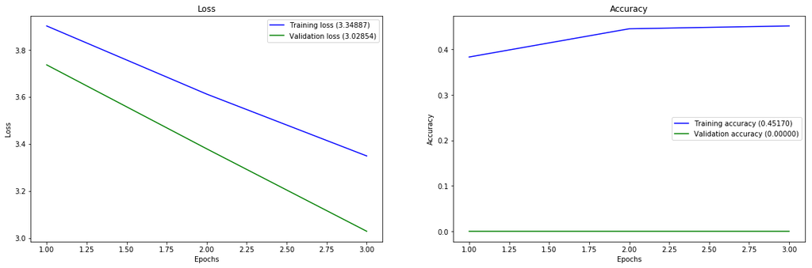

```python
print('model1')
plot_history(history_1)
```

```python
model_1_new.compile(loss='categorical_crossentropy',
             optimizer = Adamax(),
             metrics=['accuracy'])

history_1_new = model_1_new.fit(X_train,
          Y_train,
          batch_size=128,
          epochs=3,
          verbose=1,
          validation_data = (X_test,Y_test),
          callbacks=[metrics]
         )
```

```
Train on 57472 samples, validate on 166 samples
val_precision: 0.0
```

```
val_precision: 0.0
val_precision: 0.0
```

```
model_1_new
```

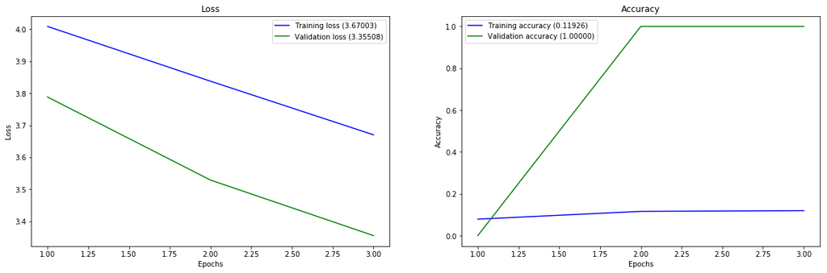

```python
print('model_1_new')
plot_history(history_1_new)
```